# Hotspots of tree mortality Bavaria

Maria Potterf

10/26/2021

# 1 Identify hotspots of tree mortality for field work in 2022

- Based on forest disturbances map (Senf et al. 2020)
- in yearly steps, 1986-2020
- mortality in Bavaria from drought, starting from 2018

## 1.1 Process:

Create hexagon grids of different sizes to understand how the cell size affects the location of the hotspots. The smaller plots size will help to locate the specific high mortality nested within the larger grid size to facilitate the field work to search for triplets. The size of hexagons should be scalable for an European level estimation.

Investigated grid sizes: c(1,2,3,5,7,10,12,15,20, 25, 30, 35, 40, 50,60) km. Represented here: 3,5,12 km

Estimate mortality based on two approaches:

- from absolute values of disturbed area in Bavaria 2018-2020 (total hectares)
- from disturbance anomalies values (difference from mean mortality 1986-2015), ranges until 500% mortality increase

## 1.2 Mortality estimation based on sum of disturbances >2018 (ha)

Process:

- recalculate the disturbance rates & anomalies for each grid size
- classify data in quantiles: >0.75 is highly damaged -> that’s where we wish to do field work in summer 2022

Get statistics given grid size: **Sum of forest mortality over 2018-2020**

Calculated as disturbance rate = sum of disturbances (2018-2020) /forest_area*100. The rate of mortality does not vary much given the grid size (stay constant at 2.4% o disturbaed forest at 75% quantile):

Table numbers represents quantiles of disturbance rates from the total disturbed forests (% of disturbed forest, (ha)):

| gridSize | Mean | 0 | 0.01 | 0.25 | 0.5 | 0.75 | 0.99 | 1 |
| --- | --- | --- | --- | --- | --- | --- | --- | --- |
| 3 | Inf (7.7) | 0 (0.1) | 0.1 (0.2) | 0.5 (1.3) | 1.2 (3.7) | 2.6 (8.6) | 15.6 (61.1) | Inf (268.7) |
| 5 | 2.1 (18.7) | 0 (0.1) | 0 (0.3) | 0.6 (4) | 1.2 (10) | 2.4 (21.6) | 13.9 (137.1) | 53.2 (605) |
| 10 | 2 (70.7) | 0 (0.1) | 0.1 (0.8) | 0.7 (20.6) | 1.3 (43.4) | 2.4 (82.8) | 12.5 (505.4) | 35.8 (1478.5) |
| 12 | 2.1 (99.9) | 0 (0.2) | 0.1 (1.2) | 0.8 (31.5) | 1.4 (65.6) | 2.4 (121) | 13.1 (572.1) | 29.7 (1740.6) |
| 25 | 2.1 (389.9) | 0.3 (0.3) | 0.3 (1.6) | 0.9 (161.3) | 1.5 (276.9) | 2.3 (472.1) | 11.1 (2291.5) | 24 (4373.5) |
| 50 | 2.2 (1238.6) | 0.2 (0.1) | 0.3 (0.5) | 1.1 (284.5) | 1.5 (1051.1) | 2.3 (1444.1) | 11 (6745.9) | 12.1 (7259) |

How many mortality hotspots we have? Given the grid size, we have ‘n’ polygons:

| gridSize | quantile | n |
| --- | --- | --- |
| 3 | 4 | 2738 |
| 5 | 4 | 1125 |
| 10 | 4 | 298 |
| 12 | 4 | 211 |
| 25 | 4 | 54 |
| 50 | 4 | 17 |

### 1.2.1 Examples of forest mortality patterns (disturbance rates >2018):

given the hexagon size (yellow = 4 = high mortality):

**Hexagon size: 3 km**; yellow = high mortality, 1 = low mortality

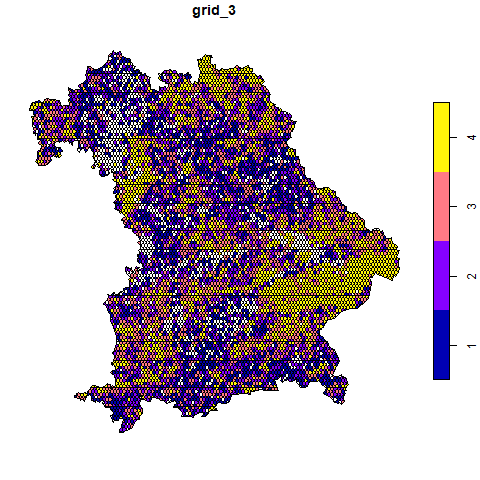

**Hexagon size: 5 km**; yellow = high mortality, 1 = low mortality

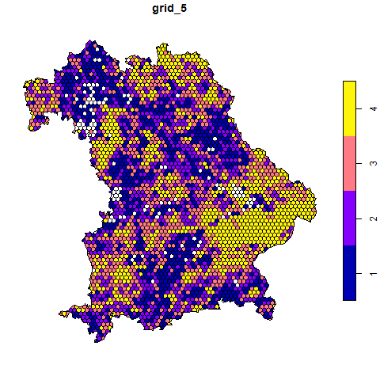

**Hexagon size: 12 km**; yellow = high mortality, 1 = low mortality

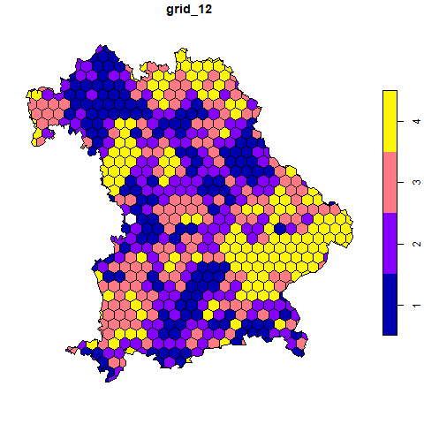

### 1.2.2 Conclude:

Mortality patterns are more or less constant over space. Smaller grids sizes will facilitate the location of the triplets. Combine the size of 12 km (for European scale) with 1-3 km hexagon size for Bavaria? We can check for overlaps between them to make sure that they do not affects the results (non dependent of scale).

## 1.3 Mortality estimation based on anomalies (compared to mean 1986-2015)

Disturbance anomaly represent the disturbances higher than mean disturbance rate over 1986-2016. Presented by years following the drought in Bavaria.

### 1.3.1 Example outputs maps for disturbance anomalies

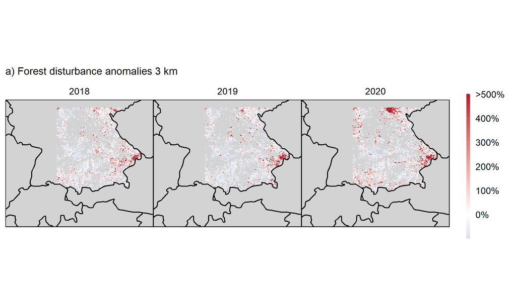

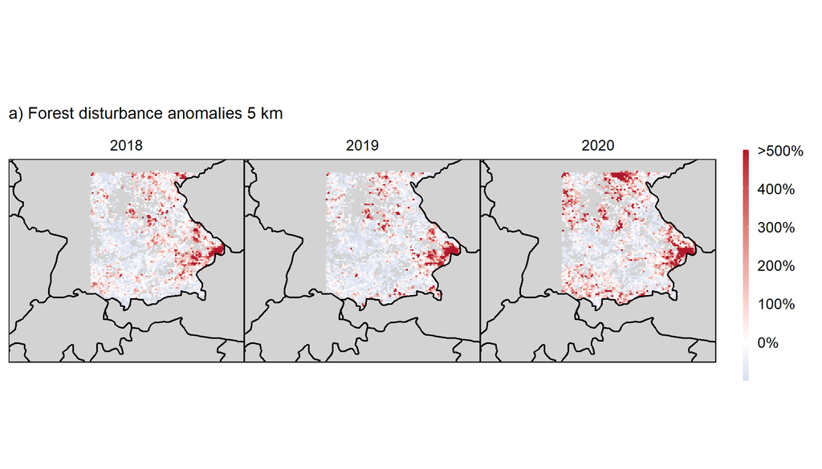

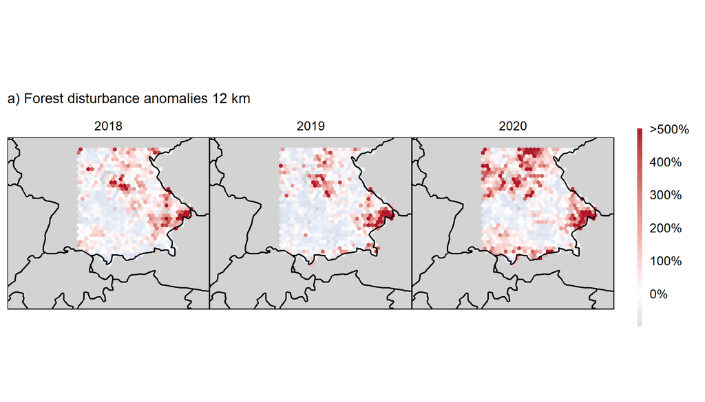

# 2 Outputs:

- spatial representation of the mortality hotspots in Bavaria -> easy to use to subset the final hotspots
- compare with forestry maps of disturbances, forest ownerships
- 1. given mortality rates;
- 2. given mortality anomalies

# 3 Next?

- finalize the hexagon size: 12 vs. 3 km?
- defin thresholds for the mortality hotspots
- overlap with forest ownerships to find ideal field samples??
- meeting how to finalize hotsport identification?